# Assignment2

Michael Nefiodovas(22969312)

Carmen Leong(22789943)

Nicholas Choong(21980614)

# Question 1

## (a) Why should you not automatically scale the data prior to a PCA or FA? Restrict your answer to one or two concise sentences.

Scaling can possibly cause information loss especially for variables with high magnitude. If the variables with high magnitude are important, scaling is not advised since scaling centres all the variables and transforms their variability and range to more comparable ranges. Moreover, if the variables in the data set have same units of measurement, scaling is not necessarily required.

## (b) The dataset ass2pop.csv is available in the LMS folder ‘Data sets’. For a description of the data see Assignment 1. Here we work with a part of the dataset only. Let Σ be the covariance matrix consisting of rows 1:11, and columns 3:13. Read the data into R. The value for Σ[1, 1] should be 0.8266. In your answer show the R commands you use to calculate the following and show the results stating clearly what each part is.

```r
ass2pop <- read.csv("ass2pop.csv", header = FALSE)
S0 = as.matrix(ass2pop[1:11,3:13])
S0
```

```
          V3        V4        V5        V6        V7       V8       V9      V10       V11       V12       V13
1   0.826600  0.085098  0.813860  0.941140 -0.094576 0.157220 0.413020 0.544060 -0.070067 -0.379050  0.723150
2   0.085098  0.772170  0.087477  0.095301 -0.113380 0.029254 0.055516 0.013586 -0.079740 -0.058024  0.042291
3   0.813860  0.087477  0.808930  0.928340 -0.042251 0.235750 0.469730 0.581750 -0.012993 -0.302510  0.731960
4   0.941140  0.095301  0.928340  1.093100 -0.082746 0.181890 0.485200 0.627510 -0.085199 -0.413400  0.892100
5  -0.094576 -0.113380 -0.042251 -0.082746  0.803680 0.619900 0.535770 0.435710  0.522590  0.722830  0.142650
6   0.157220  0.029254  0.235750  0.181890  0.619900 1.045000 0.815470 0.658660  0.719410  0.829310  0.321660
7   0.413020  0.055516  0.469730  0.485200  0.535770 0.815470 0.885550 0.756200  0.510570  0.471130  0.544810
8   0.544060  0.013586  0.581750  0.627510  0.435710 0.658660 0.756200 0.784750  0.396520  0.274940  0.615920
9  -0.070067 -0.079740 -0.012993 -0.085199  0.522590 0.719410 0.510570 0.396520  1.016400  0.691920  0.125210
10 -0.379050 -0.058024 -0.302510 -0.413400  0.722830 0.829310 0.471130 0.274940  0.691920  1.150600 -0.113900
11  0.723150  0.042291  0.731960  0.892100  0.142650 0.321660 0.544810 0.615920  0.125210 -0.113900  1.548100
```

The covariance matrix is a 11x11 square matrix giving the covariance between each pair of the first 11 variables from the first population.

### i. the eigenvalues of Σ;

```r
ev = eigen(S0)
vals = ev$values
vals
```

```
 [1] 4.8414428891 3.5168110273 0.8049944895 0.6695186459 0.4372377465 0.2438244571 0.1239747301 0.0465762465 0.0421426530 0.0078666975 0.0004904174
```

The eigenvalues of the covariance matrix encode the variability of the data in an orthogonal basis that captures as much of the data’s variability as possible.

### ii. the matrix Σ<sup>2/3</sup>;

```r
V1 = ev$vectors
vals2 = diag(vals^(2/3) )
S1 = V1 %*% vals2 %*% t( V1 )
S1
```

```
             [,1]         [,2]        [,3]        [,4]        [,5]       [,6]       [,7]         [,8]        [,9]       [,10]       [,11]
 [1,]  0.55097423  0.043824977  0.53202284  0.59708083 -0.08208317 0.07478956 0.21924834  0.319005420 -0.05286721 -0.24791854  0.36579932
 [2,]  0.04382498  0.835844641  0.04746383  0.04894243 -0.08508635 0.03004535 0.04451748 -0.001977267 -0.05461885 -0.02556934  0.01465074
 [3,]  0.53202284  0.047463830  0.53086756  0.58531690 -0.05511226 0.13214522 0.25893374  0.340655923 -0.02149901 -0.19959764  0.37040230
 [4,]  0.59708083  0.048942432  0.58531690  0.72776400 -0.06855236 0.07585321 0.26069436  0.357167887 -0.07249309 -0.26035371  0.47900278
 [5,] -0.08208317 -0.085086348 -0.05511226 -0.06855236  0.70145652 0.31976753 0.32016690  0.278732427  0.27348623  0.43838671  0.07636199
 [6,]  0.07478956  0.030045346  0.13214522  0.07585321  0.31976753 0.77108082 0.49253446  0.373737622  0.41329665  0.52914125  0.13912266
 [7,]  0.21924834  0.044517479  0.25893374  0.26069436  0.32016690 0.49253446 0.65414626  0.453457265  0.27138848  0.26158871  0.26347006
 [8,]  0.31900542 -0.001977267  0.34065592  0.35716789  0.27873243 0.37373762 0.45345726  0.565724190  0.21461427  0.14675864  0.29956013
 [9,] -0.05286721 -0.054618851 -0.02149901 -0.07249309  0.27348623 0.41329665 0.27138848  0.214614273  0.88768892  0.38079110  0.05894989
[10,] -0.24791854 -0.025569342 -0.19959764 -0.26035371  0.43838671 0.52914125 0.26158871  0.146758645  0.38079110  0.87810393 -0.06151348
[11,]  0.36579932  0.014650738  0.37040230  0.47900278  0.07636199 0.13912266 0.26347006  0.299560127  0.05894989 -0.06151348  1.21280678
```

### iii. the matrix 2Σ<sup>−1/4</sup>ΣΣ<sup>−1/4</sup> and its eigenvalues

```r
vals3 = diag(vals^(-1/4) )
S2 = V1 %*% vals3 %*% t( V1 )
mat = 2*S2%*%S0%*%S2
mat
```

```
             [,1]        [,2]        [,3]        [,4]       [,5]       [,6]       [,7]        [,8]        [,9]       [,10]       [,11]
 [1,]  0.95373655  0.05761053  0.88179563  0.94316103 -0.1413759 0.09789139 0.29775815  0.47496012 -0.08184375 -0.38155096  0.47984888
 [2,]  0.05761053  1.74377277  0.06508920  0.06457208 -0.1381399 0.05401604 0.07633015 -0.01210738 -0.08471910 -0.02937148  0.01407658
 [3,]  0.88179563  0.06508920  0.90866337  0.92222858 -0.1081073 0.20097407 0.36715267  0.50692054 -0.03929485 -0.30798393  0.48733943
 [4,]  0.94316103  0.06457208  0.92222858  1.26786709 -0.1115446 0.08286691 0.36335471  0.51509129 -0.12183553 -0.38557858  0.66371355
 [5,] -0.14137589 -0.13813987 -0.10810731 -0.11154459  1.4128098 0.41380042 0.47532679  0.43887159  0.36424069  0.64915594  0.10788904
 [6,]  0.09789139  0.05401604  0.20097407  0.08286691  0.4138004 1.43627830 0.74261589  0.53754681  0.59189457  0.81751402  0.16435516
 [7,]  0.29775815  0.07633015  0.36715267  0.36335471  0.4753268 0.74261589 1.24740659  0.68401995  0.36766788  0.35964420  0.33917846
 [8,]  0.47496012 -0.01210738  0.50692054  0.51509129  0.4388716 0.53754681 0.68401995  1.07939051  0.29850212  0.19877858  0.38448716
 [9,] -0.08184375 -0.08471910 -0.03929485 -0.12183553  0.3642407 0.59189457 0.36766788  0.29850212  1.74592985  0.52326068  0.07726484
[10,] -0.38155096 -0.02937148 -0.30798393 -0.38557858  0.6491559 0.81751402 0.35964420  0.19877858  0.52326068  1.63512469 -0.08004537
[11,]  0.47984888  0.01407658  0.48733943  0.66371355  0.1078890 0.16435516 0.33917846  0.38448716  0.07726484 -0.08004537  2.22935626
```

```r
vals4 = eigen(mat)$values
vals4
```

```
 [1] 4.40065581 3.75063249 1.79442970 1.63648238 1.32247911 0.98757168 0.70420091 0.43163061 0.41057352 0.17738881 0.04429074
```

# Question 2

## Consider the abalone data. We want to compare the performance of linear regression and PCR for the raw abalone data following the description given in Q3 of Lab 3. In the analysis we use the predictor variables Length, Height, Whole Weight, Shucked Weight, Viscera Weight and Dried-Shell Weight and we consider Rings as the response variable. Hint. Note the change of predictor variables used in Q2 compared to the variables in the Lab.

```r
coln <- c(
  "Sex", #      nominal         M, F, and I (infant)
  "Length", #       continuous  mm  Longest shell measurement
  "Diameter", #     continuous  mm  perpendicular to length
  "Height", #       continuous  mm  with meat in shell
  "Whole_weight", #     continuous  grams   whole abalone
  "Shucked_weight", #   continuous  grams   weight of meat
  "Viscera_weight", #   continuous  grams   gut weight (after bleeding)
  "Shell_weight", #     continuous  grams   after being dried
  "Rings" #         integer         +1.5 gives the age in years
)
abalone <- read_csv(file = "./abalone.csv", col_names = coln)
summary(abalone)
summary
summary(abalone)
```

```
     Sex                Length         Diameter          Height        Whole_weight    Shucked_weight   Viscera_weight
 Length:4177        Min.   :0.075   Min.   :0.0550   Min.   :0.0000   Min.   :0.0020   Min.   :0.0010   Min.   :0.0005
 Class :character   1st Qu.:0.450   1st Qu.:0.3500   1st Qu.:0.1150   1st Qu.:0.4415   1st Qu.:0.1860   1st Qu.:0.0935
 Mode  :character   Median :0.545   Median :0.4250   Median :0.1400   Median :0.7995   Median :0.3360   Median :0.1710
                    Mean   :0.524   Mean   :0.4079   Mean   :0.1395   Mean   :0.8287   Mean   :0.3594   Mean   :0.1806
                    3rd Qu.:0.615   3rd Qu.:0.4800   3rd Qu.:0.1650   3rd Qu.:1.1530   3rd Qu.:0.5020   3rd Qu.:0.2530
                    Max.   :0.815   Max.   :0.6500   Max.   :1.1300   Max.   :2.8255   Max.   :1.4880   Max.   :0.7600
  Shell_weight        Rings
 Min.   :0.0015   Min.   : 1.000
 1st Qu.:0.1300   1st Qu.: 8.000
 Median :0.2340   Median : 9.000
 Mean   :0.2388   Mean   : 9.934
 3rd Qu.:0.3290   3rd Qu.:11.000
 Max.   :1.0050   Max.   :29.000
```

```r
summary
```

```
function (object, ...)
UseMethod("summary")
<bytecode: 0x11d26c408>
<environment: namespace:base>
```

```r
# Regression
big.lm <- lm(Rings ~ Length + Height + Whole_weight + Shucked_weight + Viscera_weight + Shell_weight, data = abalone)
summary(big.lm)
```

[output not shown]

### (a) For the regular linear regression use forward selection and state the order in which the variables are chosen. Calculate the residual standard deviation for each number of predictors. Hint. you may make use of the code in Lab 3.

```r
glancerows <- data.frame()
fm.fwd <- fm.null <- lm(Rings ~ 1, abalone)
summary(lm(fm.fwd))
row1 <- data.frame(modelno = 0, variable = "Intercept", sigma = glance(lm(fm.fwd))$sigma)
glancerows <- rbind(glancerows, row1)
add1(fm.fwd, big.lm, test = "F")
```

[output not shown]

```r
fm.fwd <- update(fm.fwd, . ~ . + Shell_weight)
row1 <- data.frame(modelno = 1, variable = "Shell_weight", sigma = glance(lm(fm.fwd))$sigma)
glancerows <- rbind(glancerows, row1)
add1(fm.fwd, big.lm, test = "F")
```

```r
fm.fwd <- update(fm.fwd, . ~ . + Shucked_weight)
row1 <- data.frame(modelno = 2, variable = "Shucked_weight", sigma = glance(lm(fm.fwd))$sigma)
glancerows <- rbind(glancerows, row1)
add1(fm.fwd, big.lm, test = "F")
```

```r
fm.fwd <- update(fm.fwd, . ~ . + Length)
row1 <- data.frame(modelno = 3, variable = "Length", sigma = glance(lm(fm.fwd))$sigma)
glancerows <- rbind(glancerows, row1)
add1(fm.fwd, big.lm, test = "F")
```

```r
fm.fwd <- update(fm.fwd, . ~ . + Whole_weight)
row1 <- data.frame(modelno = 4, variable = "Whole_weight", sigma = glance(lm(fm.fwd))$sigma)
glancerows <- rbind(glancerows, row1)
add1(fm.fwd, big.lm, test = "F")
```

```r
fm.fwd <- update(fm.fwd, . ~ . + Height)
row1 <- data.frame(modelno = 5, variable = "Height", sigma = glance(lm(fm.fwd))$sigma)
glancerows <- rbind(glancerows, row1)
add1(fm.fwd, big.lm, test = "F")
```

```r
fm.fwd <- update(fm.fwd, . ~ . + Viscera_weight)
row1 <- data.frame(modelno = 6, variable = "Viscera_weight", sigma = glance(lm(fm.fwd))$sigma)
glancerows <- rbind(glancerows, row1)
```

```r
glancerows
```

| modelno | variable | sigma |
| --- | --- | --- |
| 0 | Intercept | 3.224169 |
| 1 | Shell_weight | 2.510500 |
| 2 | Shucked_weight | 2.339087 |
| 3 | Length | 2.288719 |
| 4 | Whole_weight | 2.259299 |
| 5 | Height | 2.242614 |
| 6 | Viscera_weight | 2.227005 |

Shell_weight, Shucked_weight, Length, Whole_weight, Height, Viscera_weight

### (b) Carry out PCR on the raw data using the same variables and response as in part (a). For each additional principal component you add to the regression model as predictor, calculate the residual standard deviation and list which of the variables has the heighest absolute weight in the respective principal component.

```r
pcr_model1 <- pcr(Rings ~ Whole_weight, data = abalone, scale = F, validation = "CV")
summary(pcr_model1)
```

```
Data:   X dimension: 4177 1
    Y dimension: 4177 1
Fit method: svdpc
Number of components considered: 1

VALIDATION: RMSEP
Cross-validated using 10 random segments.
       (Intercept)  1 comps
CV           3.225    2.714
adjCV        3.225    2.714

TRAINING: % variance explained
       1 comps
X        100.0
Rings     29.2
```

```r
pcr_model2 <- pcr(Rings ~ Whole_weight + Shucked_weight, data = abalone, scale = F, validation = "CV")
summary(pcr_model2)
```

```
Data:   X dimension: 4177 2
    Y dimension: 4177 1
Fit method: svdpc
Number of components considered: 2

VALIDATION: RMSEP
Cross-validated using 10 random segments.
       (Intercept)  1 comps  2 comps
CV           3.225     2.75    2.354
adjCV        3.225     2.75    2.354

TRAINING: % variance explained
       1 comps  2 comps
X        99.14    100.0
Rings    27.32     46.8
```

```r
pcr_model3 <- pcr(Rings ~ Whole_weight + Shucked_weight + Length, data = abalone, scale = F, validation = "CV")
summary(pcr_model3)
```

```
Data:   X dimension: 4177 3
    Y dimension: 4177 1
Fit method: svdpc
Number of components considered: 3

VALIDATION: RMSEP
Cross-validated using 10 random segments.
       (Intercept)  1 comps  2 comps  3 comps
CV           3.225    2.744    2.302    2.303
adjCV        3.225    2.744    2.302    2.303

TRAINING: % variance explained
       1 comps  2 comps  3 comps
X        98.52    99.36   100.00
Rings    27.65    49.16    49.17
```

```r
pcr_model4 <- pcr(Rings ~ Whole_weight + Shucked_weight + Length + Shell_weight, data = abalone, scale = F, validation = "CV")
summary(pcr_model4)
```

```
Data:   X dimension: 4177 4
    Y dimension: 4177 1
Fit method: svdpc
Number of components considered: 4

VALIDATION: RMSEP
Cross-validated using 10 random segments.
       (Intercept)  1 comps  2 comps  3 comps  4 comps
CV           3.225    2.729    2.273    2.262    2.263
adjCV        3.225    2.729    2.272    2.262    2.263

TRAINING: % variance explained
       1 comps  2 comps  3 comps  4 comps
X        98.04    99.19    99.79   100.00
Rings    28.45    50.42    50.89    50.94
```

```r
pcr_model5 <- pcr(Rings ~ Whole_weight + Shucked_weight + Length + Shell_weight + Height, data = abalone, scale = F, validation = "CV")
summary(pcr_model5)
```

```
Data:   X dimension: 4177 5
    Y dimension: 4177 1
Fit method: svdpc
Number of components considered: 5

VALIDATION: RMSEP
Cross-validated using 10 random segments.
       (Intercept)  1 comps  2 comps  3 comps  4 comps  5 comps
CV           3.225    2.727    2.262    2.253    2.254    2.266
adjCV        3.225    2.727    2.262    2.253    2.254    2.264

TRAINING: % variance explained
       1 comps  2 comps  3 comps  4 comps  5 comps
X        97.88    99.03    99.64    99.85   100.00
Rings    28.50    50.86    51.26    51.30    51.68
```

```r
pcr_model6 <- pcr(Rings ~ Whole_weight + Shucked_weight + Length + Shell_weight + Height + Viscera_weight, data = abalone, scale = F, validation = "CV")
summary(pcr_model6)
```

```
Data:   X dimension: 4177 6
    Y dimension: 4177 1
Fit method: svdpc
Number of components considered: 6

VALIDATION: RMSEP
Cross-validated using 10 random segments.
       (Intercept)  1 comps  2 comps  3 comps  4 comps  5 comps  6 comps
CV           3.225    2.728    2.264    2.255    2.253    2.247    2.254
adjCV        3.225    2.728    2.264    2.255    2.253    2.249    2.252

TRAINING: % variance explained
       1 comps  2 comps  3 comps  4 comps  5 comps  6 comps
X        97.71    98.82    99.42    99.73    99.87   100.00
Rings    28.46    50.72    51.11    51.29    51.38    52.36
```

```r
pcr_model7 <- pcr(Rings ~ Shell_weight + Shucked_weight + Length + Whole_weight + Height + Viscera_weight, data = abalone, scale = F, validation = "CV")
summary(pcr_model7)
```

```
Data:   X dimension: 4177 6
    Y dimension: 4177 1
Fit method: svdpc
Number of components considered: 6

VALIDATION: RMSEP
Cross-validated using 10 random segments.
       (Intercept)  1 comps  2 comps  3 comps  4 comps  5 comps  6 comps
CV           3.225    2.729    2.266    2.258    2.255    2.249    2.251
adjCV        3.225    2.729    2.266    2.258    2.255    2.251    2.249

TRAINING: % variance explained
       1 comps  2 comps  3 comps  4 comps  5 comps  6 comps
X        97.71    98.82    99.42    99.73    99.87   100.00
Rings    28.46    50.72    51.11    51.29    51.38    52.36
```

### (c) In a single graph show plots of residual standard deviation resulting from your models on the y -axis against the number of variables/PC components on the x-axis.

```r
rsd_df <- data.frame(RMSEP(pcr_model6)$val[1,,])
colnames(rsd_df) <- c("pcr")
rsd_df$modelno <- glancerows$modelno
rsd_df$lm <- glancerows$sigma
rsd_df
```

|  | pcr | modelno | lm |
| --- | --- | --- | --- |
| (Intercept) | 3.224555 | 0 | 3.224169 |
| 1 comps | 2.728721 | 1 | 2.510500 |
| 2 comps | 2.266961 | 2 | 2.339087 |
| 3 comps | 2.258979 | 3 | 2.288719 |
| 4 comps | 2.256160 | 4 | 2.259299 |
| 5 comps | 2.249662 | 5 | 2.242614 |
| 6 comps | 2.253113 | 6 | 2.227005 |

```r
rsd_df2 <- tidyr::pivot_longer(rsd_df, -modelno, names_to = "type", values_to = "value")
ggplot(rsd_df2, aes(x = modelno, y = value, color = type, group = type)) +
  geom_point() +
  geom_line() +
  xlab("modelno") +
  ylab("sigma") +
  scale_color_manual(labels = c("pcr", "lm")
                     ,values = c("blue", "red")) +
  theme(legend.position = c(0.85, 0.5),
        legend.background = element_rect(fill = "white", color = "black"))
```

[output not shown]

### (d) Explain why you do not require to a variable selection method when selecting the predictors in PCR.

### (e) Comment on your findings and in particular on what approaches work better for these data and why.

# Question 3

## We consider the 13-dimensional wine recognition data of Example 4.6 and Lab 4. The data are available in the Data Sets folder. Here we want to compare a factor analysis of all observations with those obtained from cultivar 1 and cultivar 2. The cultivar membership of the observations is given in column 1 of the data set. For part of this analysis you may report the relevant results obtained in the lab. You may find it useful to create two data frames: one for the complete data and a separate one for the first two cultivars of the data. We refer to the latter as the *cultivar12* data. Hint. use the R command factanal from the stats library.

```r
cultivar = read.table(file = 'wine.tsv', sep = ',')

cultivar12 = cultivar[cultivar$V1 != 3, 2:14]
cultivar12
```

|  | V2 | V3 | V4 | V5 | V6 | V7 | V8 | V9 | V10 | V11 | V12 | V13 | V14 |
| --- | --- | --- | --- | --- | --- | --- | --- | --- | --- | --- | --- | --- | --- |
| 1 | 14.23 | 1.71 | 2.43 | 15.6 | 127 | 2.80 | 3.06 | 0.28 | 2.29 | 5.64 | 1.040 | 3.92 | 1065 |
| 2 | 13.20 | 1.78 | 2.14 | 11.2 | 100 | 2.65 | 2.76 | 0.26 | 1.28 | 4.38 | 1.050 | 3.40 | 1050 |
| 3 | 13.16 | 2.36 | 2.67 | 18.6 | 101 | 2.80 | 3.24 | 0.30 | 2.81 | 5.68 | 1.030 | 3.17 | 1185 |
| 4 | 14.37 | 1.95 | 2.50 | 16.8 | 113 | 3.85 | 3.49 | 0.24 | 2.18 | 7.80 | 0.860 | 3.45 | 1480 |
| 5 | 13.24 | 2.59 | 2.87 | 21.0 | 118 | 2.80 | 2.69 | 0.39 | 1.82 | 4.32 | 1.040 | 2.93 | 735 |
| 6 | 14.20 | 1.76 | 2.45 | 15.2 | 112 | 3.27 | 3.39 | 0.34 | 1.97 | 6.75 | 1.050 | 2.85 | 1450 |
| 7 | 14.39 | 1.87 | 2.45 | 14.6 | 96 | 2.50 | 2.52 | 0.30 | 1.98 | 5.25 | 1.020 | 3.58 | 1290 |
| 8 | 14.06 | 2.15 | 2.61 | 17.6 | 121 | 2.60 | 2.51 | 0.31 | 1.25 | 5.05 | 1.060 | 3.58 | 1295 |
| 9 | 14.83 | 1.64 | 2.17 | 14.0 | 97 | 2.80 | 2.98 | 0.29 | 1.98 | 5.20 | 1.080 | 2.85 | 1045 |
| 10 | 13.86 | 1.35 | 2.27 | 16.0 | 98 | 2.98 | 3.15 | 0.22 | 1.85 | 7.22 | 1.010 | 3.55 | 1045 |

[output cut: 120 more lines]

```r
cultivar = cultivar[,2:14]
cultivar
```

| V2 | V3 | V4 | V5 | V6 | V7 | V8 | V9 | V10 | V11 | V12 | V13 | V14 |
| --- | --- | --- | --- | --- | --- | --- | --- | --- | --- | --- | --- | --- |
| 14.23 | 1.71 | 2.43 | 15.6 | 127 | 2.80 | 3.06 | 0.28 | 2.29 | 5.640000 | 1.040 | 3.92 | 1065 |
| 13.20 | 1.78 | 2.14 | 11.2 | 100 | 2.65 | 2.76 | 0.26 | 1.28 | 4.380000 | 1.050 | 3.40 | 1050 |
| 13.16 | 2.36 | 2.67 | 18.6 | 101 | 2.80 | 3.24 | 0.30 | 2.81 | 5.680000 | 1.030 | 3.17 | 1185 |
| 14.37 | 1.95 | 2.50 | 16.8 | 113 | 3.85 | 3.49 | 0.24 | 2.18 | 7.800000 | 0.860 | 3.45 | 1480 |
| 13.24 | 2.59 | 2.87 | 21.0 | 118 | 2.80 | 2.69 | 0.39 | 1.82 | 4.320000 | 1.040 | 2.93 | 735 |
| 14.20 | 1.76 | 2.45 | 15.2 | 112 | 3.27 | 3.39 | 0.34 | 1.97 | 6.750000 | 1.050 | 2.85 | 1450 |
| 14.39 | 1.87 | 2.45 | 14.6 | 96 | 2.50 | 2.52 | 0.30 | 1.98 | 5.250000 | 1.020 | 3.58 | 1290 |
| 14.06 | 2.15 | 2.61 | 17.6 | 121 | 2.60 | 2.51 | 0.31 | 1.25 | 5.050000 | 1.060 | 3.58 | 1295 |
| 14.83 | 1.64 | 2.17 | 14.0 | 97 | 2.80 | 2.98 | 0.29 | 1.98 | 5.200000 | 1.080 | 2.85 | 1045 |
| 13.86 | 1.35 | 2.27 | 16.0 | 98 | 2.98 | 3.15 | 0.22 | 1.85 | 7.220000 | 1.010 | 3.55 | 1045 |

[output cut: 168 more lines]

## (a) Scale the data and work with the scaled data. How many observations are in the cultivar12 data?

```r
cultivar_scaled = scale(cultivar, center = TRUE)
cultivar_scaled
```

```
                V2          V3          V4           V5          V6           V7            V8          V9         V10          V11         V12         V13
  [1,]  1.51434077 -0.56066822  0.23139979 -1.166303174  1.90852151  0.806721729  1.0319080692 -0.65770780  1.22143845  0.251008784  0.36115849  1.84272147
  [2,]  0.24559683 -0.49800856 -0.82566722 -2.483840525  0.01809398  0.567048088  0.7315652835 -0.81841060 -0.54318872 -0.292496232  0.40490846  1.11031723
  [3,]  0.19632522  0.02117152  1.10621386 -0.267982252  0.08810981  0.806721729  1.2121137407 -0.49700500  2.12995937  0.268262912  0.31740852  0.78636920
  [4,]  1.68679140 -0.34583508  0.48655389 -0.806974805  0.92829983  2.484437221  1.4623993954 -0.97911340  1.02925134  1.182731669 -0.42634104  1.18074072
  [5,]  0.29486844  0.22705328  1.83522559  0.450674485  1.27837900  0.806721729  0.6614853002  0.22615759  0.40027531 -0.318377423  0.36115849  0.44833648
  [6,]  1.47738706 -0.51591132  0.30430096 -1.286079296  0.85828399  1.557699140  1.3622851335 -0.17559941  0.66234866  0.729810822  0.40490846  0.33565890
  [7,]  1.71142720 -0.41744613  0.30430096 -1.465743481 -0.26196936  0.327374446  0.4912910549 -0.49700500  0.67982021  0.082781041  0.27365854  1.36384178
  [8,]  1.30493643 -0.16680747  0.88751034 -0.567422559  1.48842650  0.487156874  0.4812796287 -0.41665360 -0.59560339 -0.003489596  0.44865844  1.36384178
  [9,]  2.25341491 -0.62332789 -0.71631546 -1.645407665 -0.19195352  0.806721729  0.9518166597 -0.57735640  0.67982021  0.061213382  0.53615839  0.33565890
 [10,]  1.05857838 -0.88291793 -0.35180959 -1.046527051 -0.12193769  1.094330099  1.1220109049 -1.13981619  0.45268998  0.932546820  0.22990857  1.32158768
 [11,]  1.35420804 -0.15785609 -0.24245783 -0.447646437  0.36817315  1.046395371  1.2922051502 -1.13981619  1.37868246  0.298457635  1.27990794  0.78636920
 [12,]  1.37884384 -0.76654998 -0.16955666 -0.806974805 -0.33198519 -0.151972837  0.4011882192 -0.81841060 -0.03651359 -0.025057256  0.92990815  0.29340481
 [13,]  0.92308146 -0.54276546  0.15849862 -1.046527051 -0.75208020  0.487156874  0.7315652835 -0.57735640  0.38280376  0.233754657  0.84240820  0.40608239
 [14,]  2.15487169 -0.54276546  0.08559744 -2.423952463 -0.61204853  1.286069013  1.6626279192  0.54756319  2.12995937  0.147484019  1.27990794  0.16664254
```

[output cut: 146 more lines]

```r
cultivar12_scaled = scale(cultivar12, center = TRUE)
cultivar12_scaled
```

```
             V2           V3          V4           V5           V6          V7          V8           V9         V10          V11          V12         V13
1    1.44685785 -0.293279772  0.30131202 -0.936751502  1.761870629  0.50845446  0.77260340 -0.460465745  0.99637421  0.888944882 -0.111994363  2.03216330
2    0.28795215 -0.213731458 -0.67458688 -2.230694654  0.006501368  0.23342361  0.36597003 -0.643805858 -0.87548062  0.113933323 -0.052713959  0.93780945
3    0.24294610  0.445383141  1.10895249 -0.054517535  0.071515044  0.50845446  1.01658342 -0.277125632  1.96010145  0.913548423 -0.171274766  0.45376832
4    1.60437902 -0.020542696  0.53687383 -0.583857915  0.851679160  2.43367035  1.35544457 -0.827145971  0.79250884  2.217536125 -1.179041627  1.04303578
5    0.33295820  0.706756171  1.78198622  0.651269639  1.176747542  0.50845446  0.27108891  0.547904876  0.12531305  0.077028011 -0.111994363 -0.05131807
6    1.41310332 -0.236459548  0.36861539 -1.054382698  0.786665484  1.37021776  1.21990011  0.089554594  0.40331130  1.571693159 -0.052713959 -0.21968020
7    1.62688204 -0.111455055  0.36861539 -1.230829491 -0.253553338 -0.04160723  0.04066334 -0.277125632  0.42184451  0.649060352 -0.230555170  1.31662424
8    1.25558216  0.206738200  0.90704238 -0.348595524  1.371788571  0.14174667  0.02710889 -0.185455576 -0.93108027  0.526042644  0.006566445  1.31662424
9    2.12194856 -0.372828085 -0.57363182 -1.407276284 -0.188539661  0.50845446  0.66416784 -0.368795688  0.42184451  0.618305925  0.125127252 -0.21968020
10   1.03055192 -0.702385385 -0.23711496 -0.819120306 -0.123525985  0.83849147  0.89459341 -1.010486083  0.18091270  1.860784773 -0.289835573  1.25348844
11   1.30058820  0.218102244 -0.13615990 -0.230964328  0.331569749  0.78348530  1.12501899 -1.010486083  1.16317316  0.956604621  1.132894113  0.45376832
12   1.32309123 -0.554652802 -0.06885653 -0.583857915 -0.318567014 -0.59166892 -0.08132667 -0.643805858 -0.33801735  0.495288217  0.658650884 -0.28281600
13   0.90678529 -0.270551682  0.23400865 -0.819120306 -0.708649072  0.14174667  0.36597003 -0.368795688  0.10677984  0.864341340  0.540090077 -0.11445387
14   2.03193646 -0.270551682  0.16670528 -2.171879056 -0.578621720  1.05851614  1.62653348  0.914585101  1.96010145  0.741323632  1.132894113 -0.47222340
```

[output cut: 146 more lines]

There are 130 observations in the cultivar12 data.

## (b) Separately for the complete and for the cultivar12 data, carry out, display and report the results of the following:

### i. Calculate the sample covariance matrix of the scaled data and the eigenvalues of this matrix. What is the value of $\hat{σ}^2$ for k=2? How different are the values of $\hat{σ}^2$ for the complete and the two cultivar12 datasets? Hint. You may use the information Box 6.7 in your calculations.

```r
S1 = cov(cultivar_scaled)
val1 = eigen(S1)$values
val1
```

```
 [1] 4.7058503 2.4969737 1.4460720 0.9189739 0.8532282 0.6416570 0.5510283 0.3484974 0.2888799 0.2509025 0.2257886 0.1687702 0.1033779
```

```r
S2 = cov(cultivar12_scaled)
val2 = eigen(S2)$values
val2
```

```
 [1] 4.76329126 1.80266171 1.51098222 1.17760632 0.86441690 0.72558092 0.60146583 0.42569389 0.36925807 0.29315154 0.19816224 0.19072623 0.07700288
```

```r
sigma_hat_sq1 = (1/(13-2))*(sum(val1[3:13]))
sigma_hat_sq2 = (1/(13-2))*(sum(val2[3:13]))

sigma_hat_sq1
```

```
[1] 0.527016
```

```r
sigma_hat_sq2
```

```
[1] 0.5849134
```

### ii. Calculate and list the factor loadings for the 2-factor principal axis factoring using the value of $\hat{σ}^2$ calculated in the previous part.

```r
# Factor loading for complete cultivar dataset
Om1 = diag( rep( sigma_hat_sq1, 13 ) )
S_A1 = S1 - Om1

eig_A1 = eigen( S_A1 )

Gamma_hat_1 = eig_A1$vectors[ ,1:2]
Lambda_hat_1 =  diag( eig_A1$values[1:2]^(1/2) )
Ahat1 = Gamma_hat_1 %*% Lambda_hat_1
Ahat1
```

```
             [,1]        [,2]
 [1,] -0.29504100 -0.67883001
 [2,]  0.50121729 -0.31570222
 [3,]  0.00419282 -0.44361896
 [4,]  0.48922349  0.01486432
 [5,] -0.29026293 -0.42055185
 [6,] -0.80677348 -0.09128633
 [7,] -0.86457063  0.00471567
 [8,]  0.61026726 -0.04039350
 [9,] -0.64071874 -0.05516200
[10,]  0.18115202 -0.74387639
[11,] -0.60654976  0.39192100
[12,] -0.76896884  0.23087893
[13,] -0.58618456 -0.51216004
```

```r
# Factor loading for cultivar12 datasets
Om2 = diag( rep( sigma_hat_sq2, 13 ) )
S_A2 = S2 - Om2

eig_A2 = eigen( S_A2 )

Gamma_hat_2 = eig_A2$vectors[ ,1:2]
Lambda_hat_2 =  diag( eig_A2$values[1:2]^(1/2) )
Ahat2 = Gamma_hat_2%*% Lambda_hat_2
Ahat2
```

```
              [,1]         [,2]
 [1,] -0.731306139  0.191368509
 [2,] -0.001599091 -0.527327970
 [3,] -0.297809477 -0.391927572
 [4,]  0.395377590 -0.525165136
 [5,] -0.459622750  0.002654609
 [6,] -0.766785883 -0.147231579
 [7,] -0.807245450 -0.202261191
 [8,]  0.505090569 -0.059404908
 [9,] -0.497678257 -0.236450111
[10,] -0.782286987  0.183898642
[11,] -0.021329329  0.362116482
[12,] -0.502888280 -0.371551565
[13,] -0.761294450  0.220492655
```

### iii. Show biplots of the factor loadings.

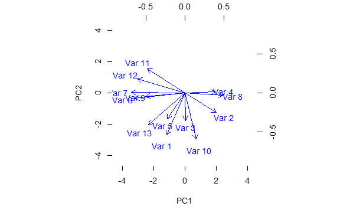

```r
wine_pr1 <- prcomp(cultivar_scaled, scale = F, center = T)
wine_pr2 <- prcomp(cultivar12_scaled, scale = F, center = T)

biplot( wine_pr1$x, Ahat1, col = c("white", "blue") )
```

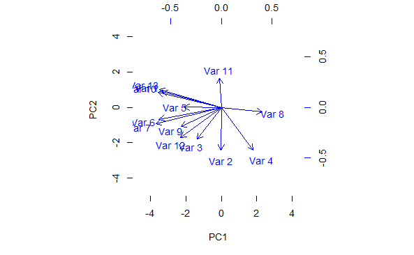

```r
biplot( wine_pr2$x, Ahat2, col = c("white", "blue") )
```

### iv. Compare the results obtained from the complete data and the cultivar12 data and comment on the main differences, similarities etc.

The eigenvalues of complete data and cultivar12 data are very similar. Hence, the values of $\hat{σ}^2$ for both data are very similar as $\hat{σ}^2$ is calculated based on the eigenvalues. The eigenvectors and the factor loadings for the complete data and cultivar12 data are quite different. The factor loadings for both dataset differ in terms of absolute value, relative order by size and the sign. This difference can also be seen in the biplots where the variables are grouped differently and have different angles.

## (c) We next turn to ML factor loadings and testing. In your calculations use the option “none” for rotation. If you use other commands, you may not achieve full marks for this question. Separately for the complete and for the cultivar12 data, carry out, display and report the results of the following:

### i. Calculate the factor loadings for the 2-factor ML without rotation. List your factor loadings and show biplots of the factor loadings.

```r
fa1 = factanal(cultivar_scaled, factors = 2, rotation = "none")$loadings
fa2 = factanal(cultivar12_scaled, factors = 2, rotation = "none")$loadings

fa1
```

```
Loadings:
    Factor1 Factor2
V2   0.225   0.695
V3  -0.444   0.198
V4           0.317
V5  -0.383  -0.106
V6   0.206   0.318
V7   0.880   0.168
V8   0.958
V9  -0.561
V10  0.656   0.120
V11 -0.242   0.881
V12  0.598  -0.385
V13  0.838  -0.234
V14  0.506   0.525

               Factor1 Factor2
SS loadings      4.253   2.036
Proportion Var   0.327   0.157
Cumulative Var   0.327   0.484
```

```r
fa2
```

```
Loadings:
    Factor1 Factor2
V2   0.562   0.626
V3          -0.196
V4   0.376
V5  -0.195  -0.516
V6   0.267   0.321
V7   0.849
V8   0.997
V9  -0.366  -0.148
V10  0.541  -0.113
V11  0.722   0.539
V12          0.111
V13  0.536  -0.149
V14  0.566   0.686

               Factor1 Factor2
SS loadings      3.842   1.631
Proportion Var   0.296   0.125
Cumulative Var   0.296   0.421
```

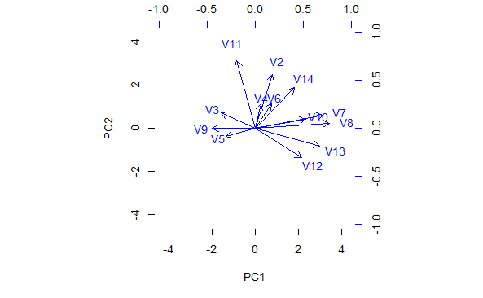

```r
biplot( wine_pr1$x, fa1, col = c("white", "blue") )
```

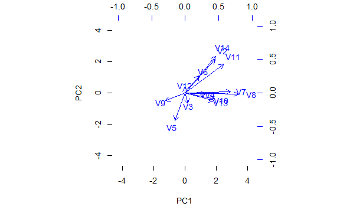

```r
biplot( wine_pr1$x, fa2, col = c("white", "blue") )
```

### ii. Carry out a sequence of hypothesis tests starting with the one-factor model.

#### A. What is the largest number $\hat{σ}^2$ of factors you can test with these data? Why can we not exceed this number?

#### B. For each k ≤ k<sup><sub>max</sub></sup> , state the number of degrees of freedom of the χ<sup>2</sup> distribution, the limiting distribution of the tes statistic −2 log LR<sub>k</sub> , and report the p-value for each set of tests.

#### C. What is the appropriate k-factor model for the complete and cultivar12 data?

### iii. Compare the results of parts (b) and (c).

# Question 4

## Consider the Boston Housing data which are available from

library ( MASS ) Boston attach ( Boston ) In Lab 5 we used these data with the 11 variables shown in Table 7.3 of Chapter 7.

```r
attach(Boston)
Boston
```

1. Use the split of the 11 variables as in Q3 of Lab 5. Calculate canonical correlation scores. List the strength of the four correlations and show the four CC score plots corresponding to (U•<sup><sub>j</sub></sup>, V•<sub>j</sub> ) for j = 1, . . . , 4.

```r
Boston.rearranged <- Boston %>% dplyr::select("crim", "indus", "nox", "dis", "rad", "ptratio", "black", "rm", "age", "tax", "medv")
envsocial <- Boston.rearranged[, 1:7]
individual <- Boston.rearranged[, 8:11]

boston.CC <- cancor(envsocial, individual)

print("The strength of the four correlations: ")
print(boston.CC$cor)

for (i in 1:4) {
  envsocialvals <- as.matrix(envsocial) %*% as.matrix(boston.CC$xcoef[, i])

  individualvals <- as.matrix(individual) %*% as.matrix(boston.CC$ycoef[, i])

  plot(envsocialvals, individualvals)
}
```

[output not shown]

2. Comment on the plots and anything unusual you notice.

c. Use all variables of the Boston Housing data other than chas and add the extra variables zn and lstat to the previous X<sup>[2]</sup> data to increase these to 6-dimensional data. Use the X<sup>[1]</sup> data of part (a). Repeat the calculations and graphics of part (a) for these data.

```r
Boston.rearranged <- Boston %>% dplyr::select("crim", "indus", "nox", "dis", "rad", "ptratio", "black", "rm", "age", "tax", "medv", "zn", "lstat")
envsocial <- Boston.rearranged[, 1:7]
individual <- Boston.rearranged[, 8:13]

boston.CC <- cancor(envsocial, individual)

print("The strength of the four correlations: ")
print(boston.CC$cor)

for (i in 1:6) {
  envsocialvals <- as.matrix(envsocial) %*% as.matrix(boston.CC$xcoef[, i])

  individualvals <- as.matrix(individual) %*% as.matrix(boston.CC$ycoef[, i])

  plot(envsocialvals, individualvals)
}
```

[output not shown]

d. Compare the results of parts (a) and (c) and comment on the differences and why they could occur.

e. Carry out a hypothesis test for the data described in part (c) using the statistic T<sub>k</sub> of Lecture 5 and the values of the correlation strengths obtained in part (c). Calculate the p-values for each statistic and report these p-values.

```r
Tk <- function(n, d1, d2, cor, k) {
  constant <- n - 0.5 * (d1 + d2 + 3)
  terms <- na.omit(1 - cor[k + 1:length(cor)]^2)
  logterm <- log(prod(terms))
  result <- - constant * logterm
  return(result)
}

n <- 506
d1 <- 7
d2 <- 6
for (k in 1:5) {
  tk <- Tk(n, d1, d2, c(boston.CC$cor), k)
  df <- (d1 - k) * (d2 - k)
  print(paste0("k=" , k, " p-value = ", pchisq(tk, df, lower.tail = FALSE)))
}
```

[output not shown]

f. Using a 1% significance level, make a decision regarding the number of nonzero correlation coefficients of the population model based on your results in part (e).

Therefore we conclude that 1,…,5 are nonzero correlation coefficients (thus there are 5).

g. Does the decision change if you replace the 1% significance level by a 5% significance level? If yes, how? Comment.